# Ordinal Logistic Regression Assignment

Lab Assignment: Does Extraversion predict ‘Often feel blue’?

Author

Caotao Qiu (Genesis)

## Question and Predictions

The `bfi` data contain 25 personality items from 2,800 people, five items per Big Five trait. Each item is answered on a 6-point scale from **Very inaccurate** to **Very accurate**.

The **chosen trait is Neuroticism**. The ordered outcome is one Neuroticism item, **N4, “Often feel blue”** The predictor is a person’s **Extraversion subscale score**, the mean of E1 to E5 with E1 and E2 reverse-keyed.

I predict that as people are more extraverted, they will give **lower** responses to “Often feel blue”. Extraversion reflects sociability, high energy, and a predisposition toward positive emotionality, which generally act as a buffer against low mood and negative affect. Therefore, more extraverted individuals should be less likely to report frequently feeling blue than more introverted individuals.

## Load and Inspect the Data

```r
data <- read_excel("./bfi.xlsx")

data<- data|>
  mutate_at(2:26, as.integer)
head(data)
```

```
# A tibble: 6 × 29
   ...1    A1    A2    A3    A4    A5    C1    C2    C3    C4    C5    E1    E2
  <dbl> <int> <int> <int> <int> <int> <int> <int> <int> <int> <int> <int> <int>
1 61617     2     4     3     4     4     2     3     3     4     4     3     3
2 61618     2     4     5     2     5     5     4     4     3     4     1     1
3 61620     5     4     5     4     4     4     5     4     2     5     2     4
4 61621     4     4     6     5     5     4     4     3     5     5     5     3
5 61622     2     3     3     4     5     4     4     5     3     2     2     2
6 61623     6     6     5     6     5     6     6     6     1     3     2     1
# ℹ 16 more variables: E3 <int>, E4 <int>, E5 <int>, N1 <int>, N2 <int>,
#   N3 <int>, N4 <int>, N5 <int>, O1 <int>, O2 <int>, O3 <int>, O4 <int>,
#   O5 <int>, gender <dbl>, education <chr>, age <dbl>
```

## Data preparation

```r
#Labels for the six response options, from lowest to highest

n_levels <- c("Very inaccurate", "Moderately inaccurate", "Slightly inaccurate", "Slightly accurate", "Moderately accurate", "Very accurate")

#Scoring keys with reverse-keyed items

keys <- list(
  Agreeableness     = c("-A1", "A2", "A3", "A4", "A5"),
  Conscientiousness = c("C1", "C2", "C3", "-C4", "-C5"),
  Extraversion      = c("-E1", "-E2", "E3", "E4", "E5"),
  Neuroticism       = c("N1", "N2", "N3", "N4", "N5"),
  Openness          = c("O1", "-O2", "O3", "O4", "-O5")
)

scores<-scoreItems(keys, data, totals = F, min = 1, max = 6)
scores_df<- scores$scores

data <- data |>
  select(N4) |>
  bind_cols(as_tibble(scores_df)) |>
  mutate(
    N4 = factor(N4, levels = 1:6, labels = n_levels, ordered = TRUE),
    highest = factor(names(keys)[max.col(scores_df, ties.method = "first")]),
    extra = Extraversion
  ) |>
  drop_na(N4, extra, highest) |>
  mutate(extra_c = extra - mean(extra))
n_analysed <- nrow(data)
extra_sd <- sd(data$extra)
extra_bar <- mean(data$extra)
```

All 25 personality items were verified and stored as integers before scoring. Each Big Five subscale was scored using `psych::scoreItems()` as the mean of its five items on the 1–6 scale after reverse-scoring negatively keyed items (with missing item responses within subscales imputed at the item median by default). After removing participants with missing values on the analysis variables, the final analytic sample was N = 2,764. Before centring, the mean Extraversion score was 4.14 (SD = 1.06).

# 1. Examine the outcomes

## The ordered outcome

```r
#Count how many people chose each response option for N4.

N4_counts <- data |>
  count(N4) |>
  mutate(p = n / sum(n))

min_cat <- N4_counts |> slice_min(n, n = 1)
N4_counts |>
  gt() |>
  cols_label(
    N4 = "Response Category",
    n = "n",
    p  = "Proportion"
  ) |>
  fmt_integer(columns = n) |>
  fmt_number(columns = p, decimals = 3)
```

| Response Category | n | Proportion |
| --- | --- | --- |
| Very inaccurate | 472 | 0.171 |
| Moderately inaccurate | 655 | 0.237 |
| Slightly inaccurate | 401 | 0.145 |
| Slightly accurate | 608 | 0.220 |
| Moderately accurate | 380 | 0.137 |
| Very accurate | 248 | 0.090 |

No category is empty or sparse. Every response option is well populated, and the smallest category (Very accurate) still contains **248** responses (8.97% of the sample), so all five thresholds can be estimated without collapsing categories.

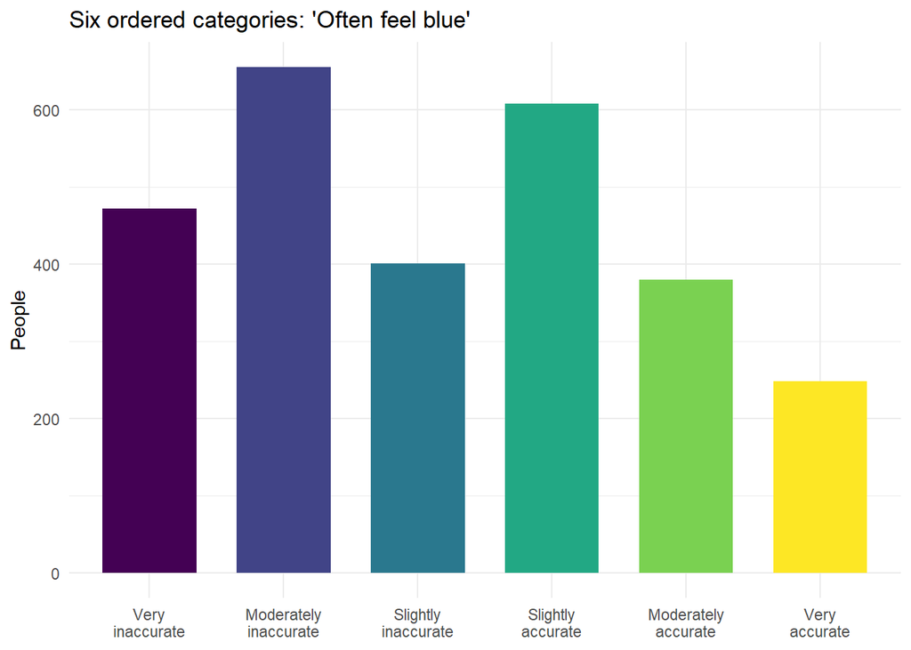

```r
#Plot the counts

plot_N4 <- ggplot(N4_counts, aes(x = N4, y = n, fill = N4)) +
  geom_col(width = 0.7) +
  scale_x_discrete(labels = scales::label_wrap(12)) +
  labs(title = "Six ordered categories: 'Often feel blue'",
       x = NULL, y = "People") +
  theme_minimal() +
  theme(legend.position = "none")
plot_N4
```

## How the predictor relates to the responses

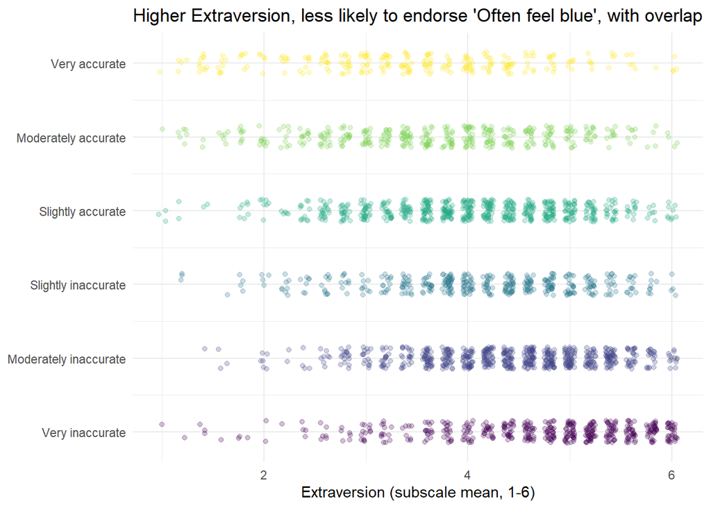

```r
plot_jitter<-ggplot(data, aes(extra, as.numeric(N4), colour = N4)) +
  geom_jitter(width = 0.05, height = 0.15, alpha = 0.25, size = 1.4) +
  scale_y_continuous(breaks = 1:6, labels = n_levels) +
  labs(title = "Higher Extraversion, less likely to endorse 'Often feel blue', with overlap",
       x = "Extraversion (subscale mean, 1-6)", y = NULL) +
  theme_minimal() +
  theme(legend.position = "none")
plot_jitter
```

The jittered dot plot reveals a clear downward pattern accompanied by substantial individual overlap. Respondents with lower Extraversion scores are concentrated more heavily in the “accurate” categories (**Slightly accurate** through **Very accurate**), whereas respondents with higher Extraversion scores cluster more densely in **Very inaccurate** and **Moderately inaccurate**. Because the outcome consists of six discrete, ordered labels rather than an interval-scaled measurement, the psychological spacing between adjacent options is not equal. Fitting an ordinary linear regression could produce a single point prediction such as “3.4” or values outside 1 to 6, so an appropriate model should instead estimate a valid probability for each of the six categories that sums to 1.

## An unordered outcome

Each person’s **dominant trait** (their highest of the five subscale scores) is a set of categories with **no built-in order**. Being highest on Openness is not “more” than being highest on Agreeableness. An outcome like this requires a baseline-category (multinomial) model, such as `nnet::multinom()`, rather than `clm()`.

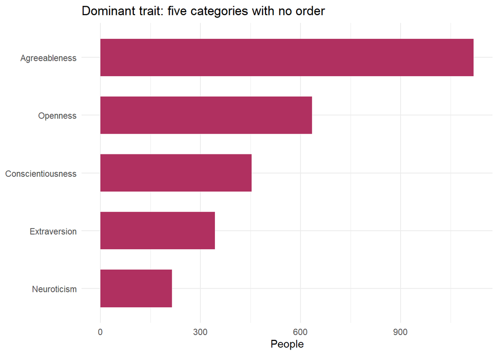

```r
ordered_dat <- data |>
  count(highest) |>
  mutate(highest = fct_reorder(highest, n))

unordered_plot <- ggplot(ordered_dat, aes(highest, n)) +
  geom_col(width = 0.65, fill = "maroon") +
  coord_flip() +
  labs(title = "Dominant trait: five categories with no order",
       x = NULL, y = "People") +
  theme_minimal()
unordered_plot
```

# 2. Cumulative probabilities

```r
obs_tab <- data |>
  count(N4) |>
  mutate(
    Probability = n / sum(n),
    CumulativeProbability = cumsum(Probability),
    CumulativeOdds = if_else(CumulativeProbability < 1,
                             CumulativeProbability / (1 - CumulativeProbability), NA_real_),
    Cumulative_Logodds = if_else(CumulativeProbability < 1,
                                 qlogis(CumulativeProbability), NA_real_)
  )

obs_tab |>
  gt() |>
  cols_label(
    N4 = "Category in N4 (j)",
    n = "n",
    Probability = "P(Y = j)",
    CumulativeProbability = "P(Y ≤ j)",
    CumulativeOdds = "Odds of ≤ j",
    Cumulative_Logodds = "Log-odds of ≤ j"
  ) |>
  fmt_integer(columns = n) |>
  fmt_number(columns = c(Probability, CumulativeProbability), decimals = 3) |>
  fmt_number(columns = c(CumulativeOdds, Cumulative_Logodds), decimals = 2) |>
  sub_missing(missing_text = "—")
```

| Category in N4 (j) | n | P(Y = j) | P(Y ≤ j) | Odds of ≤ j | Log-odds of ≤ j |
| --- | --- | --- | --- | --- | --- |
| Very inaccurate | 472 | 0.171 | 0.171 | 0.21 | −1.58 |
| Moderately inaccurate | 655 | 0.237 | 0.408 | 0.69 | −0.37 |
| Slightly inaccurate | 401 | 0.145 | 0.553 | 1.24 | 0.21 |
| Slightly accurate | 608 | 0.220 | 0.773 | 3.40 | 1.22 |
| Moderately accurate | 380 | 0.137 | 0.910 | 10.15 | 2.32 |
| Very accurate | 248 | 0.090 | 1.000 | — | — |

A cumulative probability P(Y <= j) is the probability of selecting category j or any category below it, which splits the six-point scale into a binary cutoff (at or below j versus above j). With six ordered categories, there are only **five** cumulative probabilities to model because the cumulative probability for the final category (**Very accurate**) is always fixed at P(Y <= 6) = 1 (100% of respondents fall at or below the top option) and therefore cannot vary with predictors. Furthermore, because the probability of responding above the highest category is P(Y > 6) = 1 - P(Y <= 6) = 0, the cumulative odds P(Y <= 6) / P(Y > 6) = 1 / 0 involve division by zero and are mathematically undefined (making the cumulative log-odds undefined as well).

An ordinal cumulative logit model is well suited to N4 because it preserves the natural order from **Very inaccurate** to **Very accurate** without assuming equal intervals between consecutive ratings. Conceptually, it treats the six observed categories as ordered slices of an underlying continuous tendency to feel blue, separated by five estimated thresholds. By modelling all five cumulative splits simultaneously on the log-odds scale, the model respects the category order, avoids impossible predictions outside the 1 to 6 scale, and produces coherent probabilities for every response option that always sum to 1.

# 3. The model with a centred predictor

I **centred** Extraversion earlier so that the thresholds describe a person of average Extraversion (4.14), rather than an impossible person scoring 0 on a 1 to 6 scale. Subtracting a constant shifts every Extraversion score horizontally by the same amount without altering the one-unit spacing between people, so centring changes the thresholds (which are evaluated at zero) but does **not** change the slope.

When reading the `summary()` output, the **thresholds** are the points at which a response moved from one category to the next. **Coefficients** are the **slopes** which represent the effect of Extraversion on the latent logit scale.

```r
#M0: Null model (thresholds only)

M0 <- clm(N4 ~ 1, data = data)

#M1: Extraversion model (one predictor)

M1 <- clm(N4 ~ extra_c, data = data)

summary(M1)
```

```
formula: N4 ~ extra_c
data:    data

 link  threshold nobs logLik   AIC     niter max.grad cond.H
 logit flexible  2764 -4642.32 9296.64 5(0)  7.36e-12 1.7e+01

Coefficients:
        Estimate Std. Error z value Pr(>|z|)
extra_c -0.64388    0.03445  -18.69   <2e-16 ***
---
Signif. codes:  0 '***' 0.001 '**' 0.01 '*' 0.05 '.' 0.1 ' ' 1

Threshold coefficients:
                                          Estimate Std. Error z value
Very inaccurate|Moderately inaccurate     -1.71603    0.05251 -32.680
Moderately inaccurate|Slightly inaccurate -0.41327    0.04012 -10.302
Slightly inaccurate|Slightly accurate      0.22797    0.03967   5.747
Slightly accurate|Moderately accurate      1.33484    0.04755  28.075
Moderately accurate|Very accurate          2.50379    0.06928  36.141
```

```r
coef(M1)
```

```
    Very inaccurate|Moderately inaccurate
                               -1.7160314
Moderately inaccurate|Slightly inaccurate
                               -0.4132721
    Slightly inaccurate|Slightly accurate
                                0.2279686
    Slightly accurate|Moderately accurate
                                1.3348386
        Moderately accurate|Very accurate
                                2.5037876
                                  extra_c
                               -0.6438764
```

```r
#The slope for Extraversion, pulled out by name

b <- coef(M1)[["extra_c"]]

#The five thresholds are the first five estimates

th <- coef(M1)[1:5]

#Category probabilities for a person of average Extraversion (extra_c = 0).

cum_avg <- plogis(th)

#Category probabilities for a person of average Extraversion (extra_c = 0).

cat_p <- c(cum_avg[1] - 0,          # Very inaccurate
           cum_avg[2] - cum_avg[1], # Moderately inaccurate
           cum_avg[3] - cum_avg[2], # Slightly inaccurate
           cum_avg[4] - cum_avg[3], # Slightly accurate
           cum_avg[5] - cum_avg[4], # Moderately accurate
           1 - cum_avg[5])          # Very accurate

#Probability of endorsing the item ("Slightly accurate" or higher = above threshold 3)

endorse_avg_p <- 1 - cum_avg[3]

or_tab <- tidy(M1, conf.int = TRUE, exponentiate = TRUE) |>
  filter(coef.type == "location")
```

The estimated slope is beta = -0.644, so higher Extraversion **raises** the log-odds of being at or below each threshold, which shifts responses toward the **lower** (“inaccurate”) categories.

## What the centred thresholds mean

```r
tibble(
  Category = n_levels,
  theta = c(th, NA),
  cum = c(plogis(th), 1),
  cat_p = diff(c(0, plogis(th), 1))
) |>
  gt() |>
  cols_label(
    theta = "Threshold above category",
    cum = "P(Y ≤ j)",
    cat_p = "P(Y = j)"
  ) |>
  fmt_number(columns = theta, decimals = 2) |>
  fmt_number(columns = c(cum, cat_p), decimals = 2) |>
  sub_missing(missing_text = "—")
```

| Category | Threshold above category | P(Y ≤ j) | P(Y = j) |
| --- | --- | --- | --- |
| Very inaccurate | −1.72 | 0.15 | 0.15 |
| Moderately inaccurate | −0.41 | 0.40 | 0.25 |
| Slightly inaccurate | 0.23 | 0.56 | 0.16 |
| Slightly accurate | 1.33 | 0.79 | 0.23 |
| Moderately accurate | 2.50 | 0.92 | 0.13 |
| Very accurate | — | 1.00 | 0.08 |

For a person of average Extraversion, the most likely single response is **Moderately inaccurate** (P = 0.246, or 24.57%). Their probability of endorsing the item, that is, responding **“Slightly accurate”** or higher, is 1 - P(Y <= “Slightly inaccurate”) = 1 - 0.557 = 0.443 (44.33%).

# 4. M0:Null model versus M1:Extraversion model

The null model has thresholds only. With no predictors, its thresholds reproduce the observed cumulative log-odds from Section 2 exactly:

```r
coef(M0)
```

```
    Very inaccurate|Moderately inaccurate
                               -1.5802011
Moderately inaccurate|Slightly inaccurate
                               -0.3733061
    Slightly inaccurate|Slightly accurate
                                0.2120793
    Slightly accurate|Moderately accurate
                                1.2241500
        Moderately accurate|Very accurate
                                2.3169969
```

```r
obs_tab$Cumulative_Logodds[1:5]
```

```
[1] -1.5802011 -0.3733061  0.2120793  1.2241500  2.3169969
```

Because `M0` includes no predictors, its maximum likelihood thresholds simply reproduce the sample’s marginal cumulative log-odds. Once Extraversion is added in `M1`, the thresholds become conditional on an average Extraversion score (`extra_c = 0`) and account for the variance explained by Extraversion, so they no longer match the raw unconditional log-odds.

Now I compare the two nested models with a likelihood ratio test (LRT) and AIC:

```r
#anova() on two clm models gives an LRT

lrt <- anova(M0, M1)
lrt
```

```
Likelihood ratio tests of cumulative link models:

   formula:     link: threshold:
M0 N4 ~ 1       logit flexible
M1 N4 ~ extra_c logit flexible

   no.par    AIC  logLik LR.stat df Pr(>Chisq)
M0      5 9658.1 -4824.0
M1      6 9296.6 -4642.3  363.46  1  < 2.2e-16 ***
---
Signif. codes:  0 '***' 0.001 '**' 0.01 '*' 0.05 '.' 0.1 ' ' 1
```

```r
lr_stat <- lrt$LR.stat[2]
lr_df   <- lrt$df[2]
lr_p    <- lrt$`Pr(>Chisq)`[2]
d_aic   <- AIC(M0) - AIC(M1)
```

Adding Extraversion improves fit substantially.

```r
tibble(
  Model = c("M0:Null", "M1:Extraversion"),
  Parameters = c(length(coef(M0)), length(coef(M1))),
  logLik = c(logLik(M0), as.numeric(logLik(M1))),
  AIC = c(AIC(M0), AIC(M1))
) |>
  mutate(`ΔAIC` = AIC - min(AIC)) |>
  gt() |>
  cols_label(logLik = "Log-Likelihood") |>
  fmt_integer(columns = Parameters) |>
  fmt_number(columns = c(logLik, AIC, `ΔAIC`), decimals = 1)
```

| Model | Parameters | Log-Likelihood | AIC | ΔAIC |
| --- | --- | --- | --- | --- |
| M0:Null | 5 | −4,824.0 | 9,658.1 | 361.5 |
| M1:Extraversion | 6 | −4,642.3 | 9,296.6 | 0.0 |

The likelihood ratio test shows that adding centred Extraversion significantly improves model fit over the null model, χ²(1) = 363.46, p < .001. This indicates that Extraversion explains substantial variation in responses to “Often feel blue” beyond baseline category frequencies. I select **M1** because it produces a highly significant increase in log-likelihood with just one extra parameter and is strongly preferred by AIC (ΔAIC = 361.46).

## 4b. Comparing and interpreting the chosen model

The slope, beta = -0.644, is on the latent logit scale. A one-point increase in Extraversion moves a person’s latent tendency to feel blue as reflected by N4 down by 0.644. The middle categories are each about 0.87 units wide on that scale, so one point of Extraversion shifts someone by roughly 73.67% of a middle category.

# 5. Checking proportional odds

The model assumes one shared slope across all five thresholds. `nominal_test()` checks this assumption by fitting a second model in which Extraversion gets a separate slope at each threshold—a different push at each gap—and comparing the two models with a likelihood ratio test. If giving Extraversion five separate slopes does not fit significantly better than one shared slope, the proportional odds assumption holds.

```r
nt <- nominal_test(M1)

nt_lrt <- nt["extra_c", "LRT"]
nt_df <- nt["extra_c", "Df"]
nt_p <- nt["extra_c", "Pr(>Chi)"]
nt
```

```
Tests of nominal effects

formula: N4 ~ extra_c
        Df  logLik    AIC    LRT Pr(>Chi)
<none>     -4642.3 9296.6
extra_c  4 -4640.5 9300.9 3.7289   0.4439
```

The likelihood ratio test is not statistically significant, LRT = 3.73, df = 4, p = .444. Because allowing five separate threshold-specific slopes does not significantly improve model fit over a single shared slope, **the proportional odds assumption is supported** for Extraversion. Therefore, a partial proportional odds model is **not needed** to replace `M1`, and `M1` is retained as the primary model.

Below, the unconstrained nominal model (`m_nom`) is fit solely to extract the five threshold-specific odds ratios and 95% confidence intervals for the diagnostic coefficient plot (flipping the sign of each nominal coefficient before exponentiating so every odds ratio describes responding **above** the threshold).

```r
m_nom <- clm(N4 ~ 1, nominal = ~ extra_c, data = data)
anova(M1, m_nom)
```

```
Likelihood ratio tests of cumulative link models:

      formula:     nominal: link: threshold:
M1    N4 ~ extra_c ~1       logit flexible
m_nom N4 ~ 1       ~extra_c logit flexible

      no.par    AIC  logLik LR.stat df Pr(>Chisq)
M1         6 9296.6 -4642.3
m_nom     10 9300.9 -4640.5  3.7289  4     0.4439
```

```r
coef(m_nom)
```

```
    Very inaccurate|Moderately inaccurate.(Intercept)
                                           -1.7397097
Moderately inaccurate|Slightly inaccurate.(Intercept)
                                           -0.4214613
    Slightly inaccurate|Slightly accurate.(Intercept)
                                            0.2229254
    Slightly accurate|Moderately accurate.(Intercept)
                                            1.3362727
        Moderately accurate|Very accurate.(Intercept)
                                            2.5061251
        Very inaccurate|Moderately inaccurate.extra_c
                                            0.6914999
    Moderately inaccurate|Slightly inaccurate.extra_c
                                            0.6525004
        Slightly inaccurate|Slightly accurate.extra_c
                                            0.6033533
        Slightly accurate|Moderately accurate.extra_c
                                            0.6445688
            Moderately accurate|Very accurate.extra_c
                                            0.6463844
```

```r
nom_est <- coef(m_nom)[6:10]
nom_se <- sqrt(diag(vcov(m_nom)))[6:10]

threshold_or <- tibble(
  Threshold = c("Very inaccurate | Moderately inaccurate",
                "Moderately inaccurate | Slightly inaccurate",
                "Slightly inaccurate | Slightly accurate",
                "Slightly accurate | Moderately accurate",
                "Moderately accurate | Very accurate"),
  Estimate = nom_est,
  SE = nom_se,
  OR = exp(-Estimate),
  low = exp(-(Estimate + 1.96 * SE)),
  high = exp(-(Estimate - 1.96 * SE))
)
```

# 6. Interpreting the coefficient by changing odds ratios to probabilities

```r
or_tab <- tidy(M1, conf.int = TRUE, exponentiate = TRUE) |>
  filter(coef.type == "location")

or_est  <- or_tab$estimate
or_low  <- or_tab$conf.low
or_high <- or_tab$conf.high
or_p    <- or_tab$p.value
pct_dec <- 100 * (1 - or_est)
```

**Extraversion:** OR = e^beta = 0.53, 95% CI [0.49, 0.56], p < .001. Each one-point increase in Extraversion multiplies the odds of responding **above any threshold** (for example, *Slightly accurate* or higher versus lower) by 0.53. In plain language, that is a **47.47% decrease** in the odds of giving a higher endorsement of “Often feel blue” per one-point increase in Extraversion.

```r
logodds_3 <- th[3] - b * (3 - extra_bar)
prob_3    <- 1 - plogis(logodds_3)
odds_3    <- prob_3 / (1 - prob_3)

logodds_4 <- th[3] - b * (4 - extra_bar)
prob_4    <- 1 - plogis(logodds_4)
odds_4    <- prob_4 / (1 - prob_4)

logodds_5 <- th[3] - b * (5 - extra_bar)
prob_5    <- 1 - plogis(logodds_5)
odds_5    <- prob_5 / (1 - prob_5)

logodds_6 <- th[3] - b * (6 - extra_bar)
prob_6    <- 1 - plogis(logodds_6)
odds_6    <- prob_6 / (1 - prob_6)

prob_tab <- tibble(
  Extraversion = c(3, 4, 5, 6),
  Prob = c(prob_3, prob_4, prob_5, prob_6),
  Odds = c(odds_3, odds_4, odds_5, odds_6)
) |>
  mutate(
    Odds_Factor = Odds / lag(Odds),
    Prob_Change = Prob - lag(Prob)
  )

prob_tab |>
  gt() |>
  cols_label(
    Prob        = "P(Slightly accurate or higher)",
    Odds        = "Odds of ≥ Slightly accurate",
    Odds_Factor = "Odds Ratio vs. Prior Step",
    Prob_Change = "ΔP"
  ) |>
  fmt_integer(columns = Extraversion) |>
  fmt_number(columns = c(Prob, Odds, Odds_Factor, Prob_Change), decimals = 3) |>
  sub_missing(missing_text = "—")
```

| Extraversion | P(Slightly accurate or higher) | Odds of ≥ Slightly accurate | Odds Ratio vs. Prior Step | ΔP |
| --- | --- | --- | --- | --- |
| 3 | 0.624 | 1.662 | — | — |
| 4 | 0.466 | 0.873 | 0.525 | −0.158 |
| 5 | 0.314 | 0.459 | 0.525 | −0.152 |
| 6 | 0.194 | 0.241 | 0.525 | −0.120 |

Each one-point step multiplies the odds by the **exact same factor** (0.525, equal to the model OR) at every step from 3 to 6. The **probability**, however, does not change by the same amount at each step: it falls by **0.158** (15.83 percentage points) from 3 to 4, but by only **0.120** (12.03 percentage points) from 5 to 6. This occurs because probabilities are bounded between 0 and 1 and follow an S-shaped logistic curve. A constant shift on the log-odds scale produces its largest probability changes near P = 0.5 and progressively smaller changes as probabilities approach 0 or 1.

# 7. Predicted probabilities and odds ratios

## 7a. Predicted category probabilities

```r
pred <- ggpredict(M1, terms = "extra_c [all]")
```

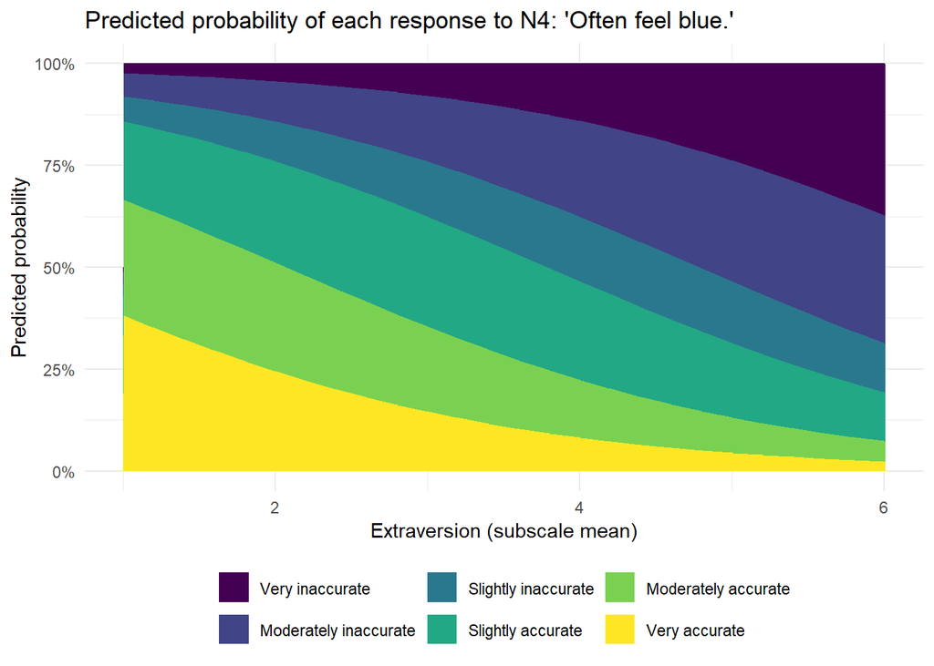

Predicted category probabilities for N4 (‘Often feel blue’) across the Extraversion scale.

```r
pred |>
  as.data.frame() |>
  mutate(
    response.level = if (all(as.character(response.level) %in% n_levels)) {
      factor(as.character(response.level), levels = n_levels, ordered = TRUE)
    } else {
      factor(response.level, labels = n_levels, ordered = TRUE)
    },
    extra = x + extra_bar
  ) |>
  ggplot(aes(extra, predicted, fill = response.level)) +
  geom_area(position = "stack") +
  scale_y_continuous(labels = scales::percent) +
  guides(fill = guide_legend(nrow = 2)) +
  labs(
    title = "Predicted probability of each response to N4: 'Often feel blue.'",
    x = "Extraversion (subscale mean)",
    y = "Predicted probability",
    fill = NULL
  ) +
  theme_minimal() +
  theme(legend.position = "bottom")
```

At low Extraversion, much of the probability sits in the “accurate” categories. As Extraversion rises, it moves toward *Very inaccurate* and *Moderately inaccurate*. At every value of Extraversion, the six probabilities sum to 1, which is why the stack always reaches 100%.

## 7b. Coefficient plot of cumulative odds ratios

The plot shows the shared proportional-odds OR alongside the threshold-specific ORs from Section 5, so it also works as a visual check of proportional odds.

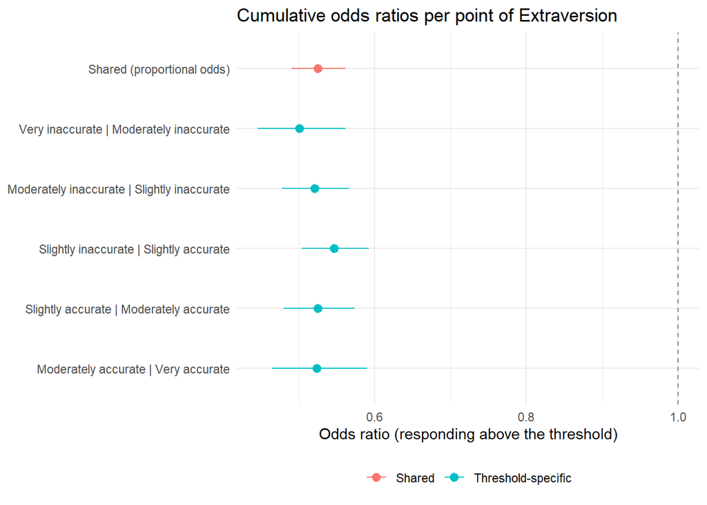

```r
bind_rows(
  tibble(
    Threshold = "Shared (proportional odds)", OR = or_tab$estimate,
         low = or_tab$conf.low, high = or_tab$conf.high, type = "Shared"),
  threshold_or |> transmute(Threshold, OR, low, high, type = "Threshold-specific")
) |>
  mutate(
    Threshold = fct_rev(fct_inorder(Threshold))) |>
  ggplot(aes(OR, Threshold, colour = type)) +
  geom_vline(xintercept = 1, linetype = "dashed", colour = "grey50") +
  geom_pointrange(aes(xmin = low, xmax = high)) +
  labs(title = "Cumulative odds ratios per point of Extraversion",
       x = "Odds ratio (responding above the threshold)", y = NULL, colour = NULL) +
  theme_minimal() +
  theme(legend.position = "bottom")
```

Every interval sits well below 1 (the dashed line). The threshold-specific estimates also cluster around the shared estimate, which is what proportional odds implies.

# 8. Results

A cumulative logit (proportional odds) regression model was fit to test whether mean-centred Extraversion subscale scores predict ordered responses to the Neuroticism item N4 (“Often feel blue.”) in a sample of N = 2,764 participants. All six response categories were well represented (the smallest category, Very accurate, contained n = 248 responses), so no categories were sparse or collapsed. Compared with a threshold-only null model, adding Extraversion significantly improved model fit, χ²(1) = 363.46, p < .001, ΔAIC = 361.46. Higher Extraversion was significantly associated with lower odds of giving a higher response to “Often feel blue.”, OR = 0.53, 95% CI [0.49, 0.56], p < .001, indicating that each one-point increase in Extraversion lowered the odds of responding above any threshold by approximately 47.47%.